# Cumulative Distribution Function (CDF) & Quantiles

Rajitha M. Silva

### Definition: Cumulative Distribution Function (cdf)

For any random variable $X$, the **cdf** is
$$F_X(t) = \Pr(X \le t).$$

This single function determines probabilities of all events that can be expressed in terms of $X$.

### From Events to the CDF

For real numbers $a \le b$,
$$\Pr(a < X \le b) = F_X(b) - F_X(a).$$

(Other combinations of strict/weak inequalities give the same value for continuous $X$; for discrete $X$ they may differ by point masses.)

A useful identity for discrete points is
$$\Pr(X = x) = F_X(x) - F_X(x-0),$$
where $F_X(x-0)$ is the left limit of $F_X$ at $x$.

### Properties of Every CDF

1. **Non-decreasing:** if $t_1 < t_2$, then $F_X(t_1) \le F_X(t_2)$.
2. **Limits:** $\displaystyle \lim_{t\to -\infty}F_X(t)=0,\quad \lim_{t\to \infty}F_X(t)=1.$
3. **Right-continuous:** $\displaystyle \lim_{h\downarrow 0} F_X(t+h)=F_X(t).$  
   – right-continuous allows jumps but forbids - holes - when you approach from the right.

## Example: Dartboard CDF (Distance from the Bullseye)

A dart is thrown at a **circular dartboard** of radius $R$. **Assume the dart always hits the board and, conditional on a hit, the landing point is uniformly distributed over the face of the board** (i.e., any two regions of equal area are equally likely to be hit).

Let $X$ be the **distance from the dart’s landing point to the bullseye (center)**.

**Task:** Derive the cumulative distribution function (cdf) of $X$, namely
$$F_X(t) = \Pr(X \le t),$$
for all real $t$.

### Solution

Because the hit is **uniform over area**, probability is proportional to area.

1. **Event geometry**
   - For $0\le t\le R$, the event $\{X\le t\}$ is a disk of radius $t$.
   - Area of that disk: $\pi t^{2}$.
   - Area of the whole board: $\pi R^{2}$.

   Hence
   $$\Pr(X\le t)=\frac{\pi t^{2}}{\pi
   R^{2}}=\left(\frac{t}{R}\right)^{2},\qquad 0\le t\le R.$$
2. **Outside the feasible range**
   - If $t<0$: distances cannot be negative $\;\Rightarrow\; F_X(t)=0$.
   - If $t>R$: the dart always lands within distance $R$ $\;\Rightarrow\; F_X(t)=1$.

#### Piecewise form

$$\boxed{
F_X(t)=
\begin{cases}
0, & t<0,\\[6pt]
\left(\dfrac{t}{R}\right)^{2}, & 0\le t\le R,\\[10pt]
1, & t>R.
\end{cases}}$$

### Example – Number of Heads in Three Tosses

Experiment: toss a fair coin three times, and record the face up at each trial.  
Random variable: $X=$ total number of heads.

- There are $2^3 = 8$ equally‐likely outcome sequences.
- Exactly one sequence has 0 heads (ttt) → $1/8$.
- Exactly one sequence has 3 heads (hhh) → $1/8$.
- $\binom{3}{1}=3$ sequences have 1 head → $3/8$.
- $\binom{3}{2}=3$ sequences have 2 heads → $3/8$.

#### Building the cdf $F_X(t)=\Pr(X\le t)$

1. **$t<0$**  
   No outcome gives $X<0$ ⇒ $F_X(t)=0$.
2. **$0\le t<1$**
   Only $X=0$ satisfies $X\le t$.
   $$F_X(t)=\Pr(X=0)=\frac18.$$
3. **$1\le t<2$**
   $X$ can be 0 or 1.
   $$F_X(t)=\Pr(X=0)+\Pr(X=1)=\frac18+\frac38=\frac12.$$
4. **$2\le t<3$**
   $X$ can be 0,1,2.
   $$F_X(t)=\frac18+\frac38+\frac38=\frac78.$$
5. **$t\ge 3$**  
   All possibilities counted ⇒ $F_X(t)=1$.

#### Resulting piecewise form

$$\boxed{
F_X(t)=
\begin{cases}
0, & t<0,\\[4pt]
\dfrac18, & 0\le t<1,\\[10pt]
\dfrac12, & 1\le t<2,\\[10pt]
\dfrac78, & 2\le t<3,\\[10pt]
1, & t\ge 3.
\end{cases}}$$

Each step height equals the probability at that $x$; cumulative sums give the cdf.

## Example – Stepwise CDF from a Finite Support

Suppose a discrete random variable $X$ takes values in a **finite set**:

$$X \in \{-3,\ 1,\ 2,\ 5\}$$

with corresponding probabilities:

$$\boxed{
\begin{array}{c|c|c|c|c}
x & -3 & 1 & 2 & 5 \\
\hline
\Pr(X = x) & \dfrac{1}{2} & \dfrac{1}{3} & \dfrac{1}{6}
& 0 \\
\end{array}
}$$

We define the **cumulative distribution function (cdf)** of $X$ as:

$$F_X(t) = \Pr(X \le t)$$

### Stepwise Structure of the CDF

Because $X$ is a **discrete** random variable, its CDF is a **step function**:

- The function is **constant between jumps**.
- It **jumps only at values in the support of $X$**.
- Each jump has a height equal to the **probability mass at that point**.

### Piecewise Definition of the CDF

$$F_X(t) =
\begin{cases}
0, & t < -3 \\
\frac{1}{2}, & -3 \le t < 1 \\
\frac{5}{6}, & 1 \le t < 2 \\
1, & 2 \le t < 5 \\
1, & t \ge 5
\end{cases}$$

> Note: The value $x = 5$ has probability 0, so the CDF does **not jump** at that point — it remains constant at 1.

### Explanation

- For $t < -3$, no value of $X$ is less than or equal to $t$ → $F_X(t) = 0$.
- For $-3 \le t < 1$, only $X = -3$ contributes → $F_X(t) = \Pr(X = -3) = \frac{1}{2}$.
- For $1 \le t < 2$, $X = -3$ and $X = 1$ are counted → $F_X(t) = \frac{1}{2} + \frac{1}{3} = \frac{5}{6}$.
- For $2 \le t < 5$, we include $X = 2$ as well → $F_X(t) = \frac{1}{2} + \frac{1}{3} + \frac{1}{6} = 1$.
- For $t \ge 5$, we still have $F_X(t) = 1$ because all mass has been accumulated.

### Visual Insight

The CDF rises in **jumps** of:

$+\frac{1}{2}$ at $x = -3$,  
$+\frac{1}{3}$ at $x = 1$,  
$+\frac{1}{6}$ at $x = 2$.

There is **no jump at $x = 5$** because $\Pr(X = 5) = 0$.

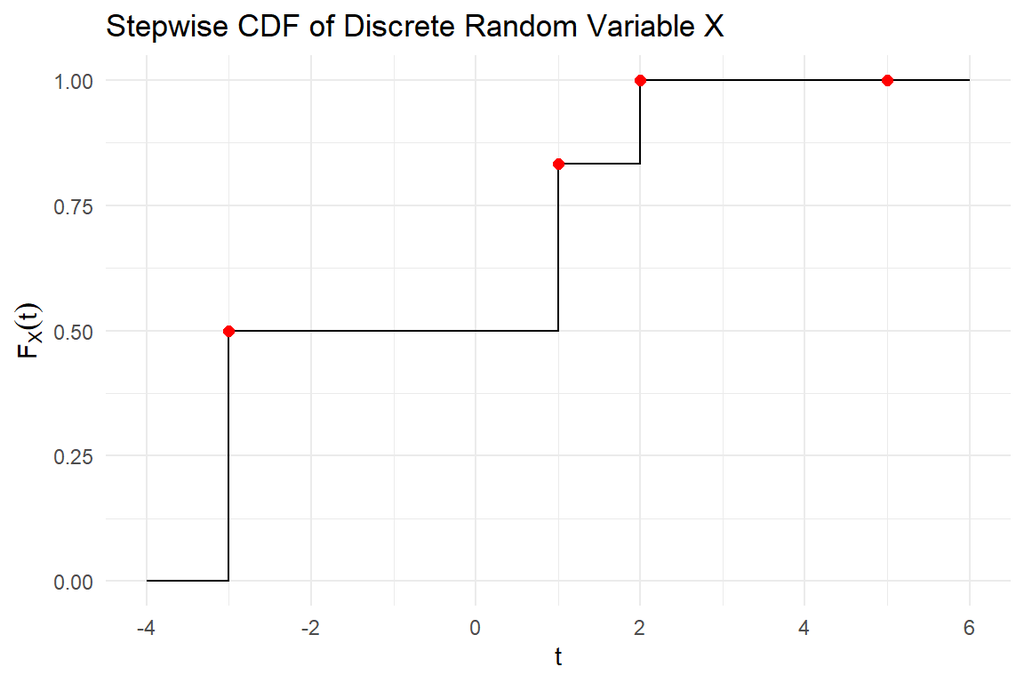

```r
library(ggplot2)

# Define values and cumulative probabilities
x_vals <- c(-3, 1, 2, 5)
probs <- c(1/2, 1/3, 1/6, 0)
cdf_vals <- cumsum(probs)

# Extended t values for plotting step function
t_vals <- c(-4, -3, 1, 2, 5, 6)
F_vals <- c(0, 1/2, 5/6, 1, 1, 1)

# Plot
ggplot(data.frame(t = t_vals, F = F_vals), aes(x = t, y = F)) +
  geom_step(direction = "hv") +
  geom_point(data = data.frame(x = x_vals, y = cdf_vals),
             aes(x = x, y = y), color = "red", size = 2) +
  labs(title = "Stepwise CDF of Discrete Random Variable X",
       x = "t", y = expression(F[X](t))) +
  theme_minimal()
```

### Example – Waiting for the First Ace

Experiment: toss a die repeatedly; $X=$ number of tosses until the first “ace” (1).
For $k=1,2,\dots$:
$$\Pr(X=k)=\left(\frac{5}{6}\right)^{k-1}\!\left(\frac{1}{6}\right).$$
The cdf is
$$\boxed{
F_X(t)=
\begin{cases}
0, & t<1,\\
\sum_{k=1}^{\lfloor t \rfloor}
\left(\frac{5}{6}\right)^{k-1}\!\left(\frac{1}{6}\right), & t\ge 1.
\end{cases}}$$

## Quantiles

### Definition 2.3 (Quantile)

For $0<p<1$, a **$p$-quantile** $t_p$ is any solution of the inequalities
$$\Pr(X \le t) \ge p, \qquad \Pr(X \ge t) \ge 1-p.$$
Equivalently,
$$F_X(t) \ge p,\qquad F_X(t-0) \le p.$$

Special names:  
- $t_{0.5}$: **median**  
- $t_{0.25},\, t_{0.75}$: **lower and upper quartiles**

### Example – Quantiles for the Target Distance

Using $F_X(t) = (t/R)^2$ on $[0,R]$, solve $(t_p/R)^2=p$.

Thus $t_p = R\sqrt{p}$;

e.g. $t_{0.25}=R/2$.

### Example – Quantiles in a Discrete Distribution

Let the random variable $X$ take the values:

$$X \in \{1, 2, 3\} \quad \text{with} \quad
\Pr(X=1) = 0.2, \quad
\Pr(X=2) = 0.6, \quad
\Pr(X=3) = 0.2$$

### Step 1: Construct the Cumulative Distribution Function (cdf)

$$F_X(x) =
\begin{cases}
0, & x < 1 \\
0.2, & 1 \le x < 2 \\
0.8, & 2 \le x < 3 \\
1, & x \ge 3
\end{cases}$$

### Step 2: Define the $p$-Quantile

For any $p \in (0,1)$, the **$p$-quantile** of a random variable $X$ is:

$$t_p = \inf\{x \in \mathbb{R} \mid F_X(x) \ge p\}$$
### Explanation

This definition uses the **infimum** (greatest lower bound) to find the smallest value $x$ such that the cumulative distribution function (cdf) $F_X(x)$ reaches or exceeds the probability level $p$.

Let’s break it down:

- The **cdf** $F_X(x)$ gives the probability that the random variable $X$ takes a value less than or equal to $x$, i.e., $F_X(x) = \Pr(X \le x)$.
- The **set** $\{x \in \mathbb{R} \mid F_X(x) \ge p\}$ contains all values of $x$ for which the cumulative probability is at least $p$.
- The **infimum** of this set is the smallest such $x$ that satisfies the inequality $F_X(x) \ge p$. This ensures that $t_p$ is the **leftmost point** where the cdf crosses the level $p$.

In the discrete case, this often involves checking intervals where the cdf jumps.

### Step 3: Compute Specific Quantiles

- **Median** ($p = 0.5$):

  We seek the smallest $x$ such that $F_X(x) \ge 0.5$.

  $$F_X(1) = 0.2 \quad \text{(too small)}\\
  F_X(2) = 0.8 \ge 0.5 \Rightarrow t_{0.5} = 2$$
- **First Quartile** ($p = 0.25$):

  $$F_X(1) = 0.2 \quad \text{(too small)}\\
  F_X(2) = 0.8 \ge 0.25 \Rightarrow t_{0.25} = 2$$
- **Third Quartile** ($p = 0.75$):

  $$F_X(2) = 0.8 \ge 0.75 \Rightarrow t_{0.75} = 2$$
- **90th Percentile** ($p = 0.90$):

  $$F_X(3) = 1.0 \ge 0.90 \Rightarrow t_{0.90} = 3$$

### Summary Table of Quantiles

$$\begin{array}{c|c}
\text{Quantile Level } p & t_p \\
\hline
0.25 & 2 \\
0.50 & 2 \\
0.75 & 2 \\
0.90 & 3 \\
\end{array}$$

Note: In a **discrete** distribution, many different $p$-quantiles may map to the same value of $X$, depending on where the jumps in the cdf occur.

### Theorem – Probability Between Quantiles

If $F$ is continuous and $0<\alpha<\beta<1$, then for any $\alpha$- and $\beta$-quantiles $t_\alpha, t_\beta$,
$$\Pr(t_\alpha \le X \le t_\beta) = \beta - \alpha.$$

**Example** With a continuous cdf, the probability that $X$ lies between its first and third quartiles is $0.75-0.25=0.5$.

### Practical Use: Probabilities via Quantiles

- To find $t_p$, solve $F_X(t_p)=p$ (when a solution exists).
- To compute $\Pr(X\in [t_\alpha, t_\beta])$ for a continuous cdf, use Theorem – Probability Between Quantiles.
- In discrete cases, use the inequality definition to locate the smallest $t$ with $F_X(t)\ge p$.